# HW3

Marco Tinga

21/05/2020

## HW3 in R Markdown

Loading the dataset and the libraries

```r
Data=read.csv('https://raw.githubusercontent.com/babakrezaee/MethodsCourses/master/LeidenUniv_MAQM2020/Datasets/R%26P_RezaeeAsadzadeh_MethodsCourse.csv')

library(dplyr)
library(broom)
library(tidyverse)
library(lmtest)
library(ggplot2)
library(jtools)
library(GGally)
library(sjPlot)
options(scipen=999)
```

## Question 1)

In order to answer the first question, we will first replicate the first two OLS models as proposed in the HW, and subsequentially call the relative summaries to evaluate the coefficients

```r
ml_OLS1=lm(Nonviolent_effective~Mandela, data=Data)

ml_OLS2=lm(Nonviolent_effective~Mandela+MalcomX, data=Data)


summ(ml_OLS1)
```

```
## MODEL INFO:
## Observations: 404 (32 missing obs. deleted)
## Dependent Variable: Nonviolent_effective
## Type: OLS linear regression
##
## MODEL FIT:
## F(1,402) = 27.73, p = 0.00
## R² = 0.06
## Adj. R² = 0.06
##
## Standard errors: OLS
## -----------------------------------------------
##                     Est.   S.E.   t val.      p
## ----------------- ------ ------ -------- ------
## (Intercept)         5.41   0.31    17.50   0.00
## Mandela             0.23   0.04     5.27   0.00
## -----------------------------------------------
```

```r
summ(ml_OLS2)
```

```
## MODEL INFO:
## Observations: 392 (44 missing obs. deleted)
## Dependent Variable: Nonviolent_effective
## Type: OLS linear regression
##
## MODEL FIT:
## F(2,389) = 15.07, p = 0.00
## R² = 0.07
## Adj. R² = 0.07
##
## Standard errors: OLS
## ------------------------------------------------
##                      Est.   S.E.   t val.      p
## ----------------- ------- ------ -------- ------
## (Intercept)          5.42   0.32    16.96   0.00
## Mandela              0.27   0.05     5.10   0.00
## MalcomX             -0.06   0.05    -1.18   0.24
## ------------------------------------------------
```

To make our evaluations I find helpful also to plot the OLS models, so to compare the values from the summary with what we would deduce from an initial graphic visualization

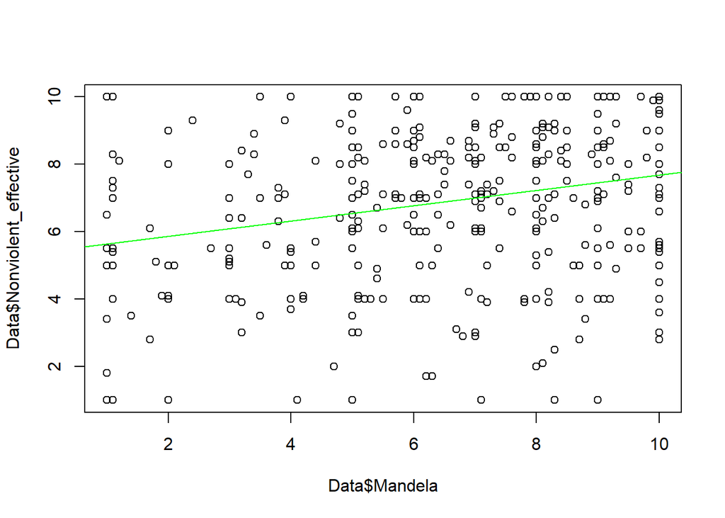

```r
# for OLS1

plot(Data$Mandela,Data$Nonviolent_effective)

abline(lm(Data$Nonviolent_effective ~ Data$Mandela), col = "green")
```

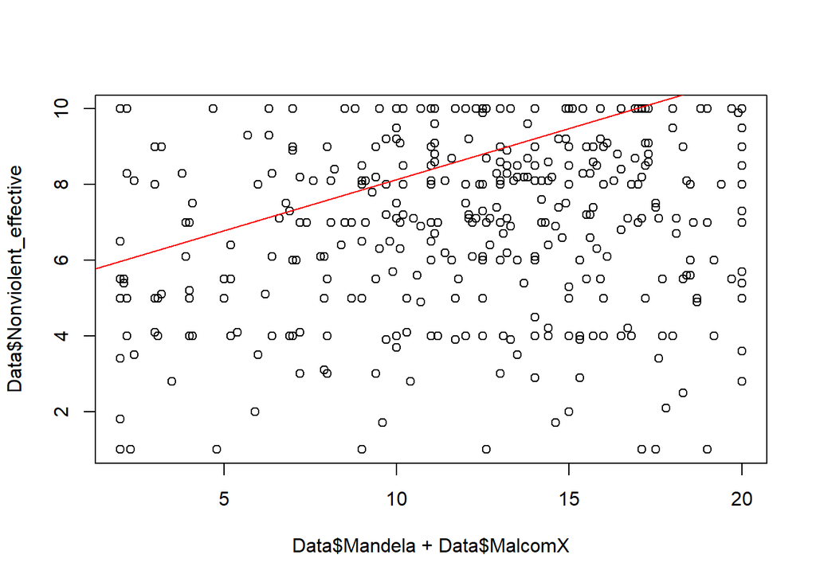

```r
# for OLS2

plot(Data$Mandela+Data$MalcomX,Data$Nonviolent_effective)

abline(lm(Data$Nonviolent_effective ~ Data$Mandela+Data$MalcomX), col = "red")
```

## For OLS1

Here we have an intercept of 5.41 and a slope of 0.23.

## For OLS2

Here we have an intercept of 5.42, the slope for Mandela’s variable of 0.27 and the slope for MalcomX variable (the control variable in this model) of -0.06.

## Interpreting the Results

Considering the p values and R square

## For OLS1

By observing a p value equal to 0 we can have a boost of confidence. However, with an R square value of only 6%, the explanatory power on how much our independent variable (support for Mandela) explain the dependent variable (opinion on effectiveness of Non-Violent resistance) is not that high. Suggesting us from the start that other factors should be taken into account as possible new main dependent variables or at least as added control variables. Nonetheless, the presence of a positive slope with a value of 0.23 shows us the existence of a positive correlation.

## For OLS2

MalcomX added as a Control Variable

As we can observe, whereas the p value for Mandela’s variable stayed equal to 0, we immediately notice three different variations in the results, when we add the support for MalcomX as a control variable: firstly, we see how the slope for Malcom X is negative, showing as a negative correlation; secondly, and most importantly, the p value for the control variable is way higher than the accepted norm, showing us that we cannot reject the null hypothesis for this control variable. It is statistically insignificant. This would suggest that the addition of Malcom X as a control variable does not alter much the findings on the effect of the support for Mandela in relation to opinions of the effectiveness of non-violent resistance, as it indeed would be logically to expect. Lastly, as it would be reasonable to expect, given the little contribution brought by adding Malcom X as a control variable, the explanatory power of OLS2 has not considerably increased in respect of OLS1, and in fact, it has increased just by a 1%.

## Question 2)

Here we are calculating the predicted value of support for the effectiveness of non-violent resistance when the opinion/support for Mandela is expressed at a level of 4 and for Malcom X at a level of 9, by substituting these values in OLS1 and OLS2 functions. OLS1 Nonviolent_effective=5.41+.23×Mandela+ϵ –> Nonviolent_effective=5.41+0.23×4+ϵ –> Nonviolent_effective=6.33 OLS2 Nonviolent_effective=5.42+0.27×Mandela−0.06×MalcolmX+ϵ –> Nonviolent_effective=5.42+0.27×4−0.06×9+ϵ –> Nonviolent_effective=5.42+1.08-0.54 –>Nonviolent_effective=5.96. If we observe the plots proposed earlier, these values for our dependent variable seems to be generally in line with what it could have been expected by an initial observation. As expected, controlling for the opinion on Malcom X does not seem to change considerably the predicted value on the effect of the opinion on Mandela on the support for the effectiveness of Non-violent resistance.

## Question 3)

For this question we will create a third OLS model where we will add additional control variables of demographic nature alongside the initial control variable of Malcom X, where the support/opinion for Mandela will remain our main independent variable.

First of all, we shall create this new model and call it ml_OLS3

```r
ml_OLS3=lm(Nonviolent_effective~Mandela+MalcomX+Age+Marriage+Gender, data=Data)

summ(ml_OLS3)
```

```
## MODEL INFO:
## Observations: 392 (44 missing obs. deleted)
## Dependent Variable: Nonviolent_effective
## Type: OLS linear regression
##
## MODEL FIT:
## F(5,386) = 6.63, p = 0.00
## R² = 0.08
## Adj. R² = 0.07
##
## Standard errors: OLS
## ---------------------------------------------------
##                         Est.   S.E.   t val.      p
## -------------------- ------- ------ -------- ------
## (Intercept)             6.03   0.83     7.25   0.00
## Mandela                 0.26   0.05     4.85   0.00
## MalcomX                -0.05   0.05    -1.14   0.26
## Age                    -0.01   0.02    -0.30   0.76
## MarriageSingle         -0.16   0.40    -0.40   0.69
## GenderMale             -0.40   0.24    -1.68   0.09
## ---------------------------------------------------
```

Once ml_OLS3 has been created, to estimate the model, and plot the predicted effects of the various independent variables on the participants’ opinion/attitude for the effectiveness of non-violent resistance, we will generate an effect plot for each one of these variables.

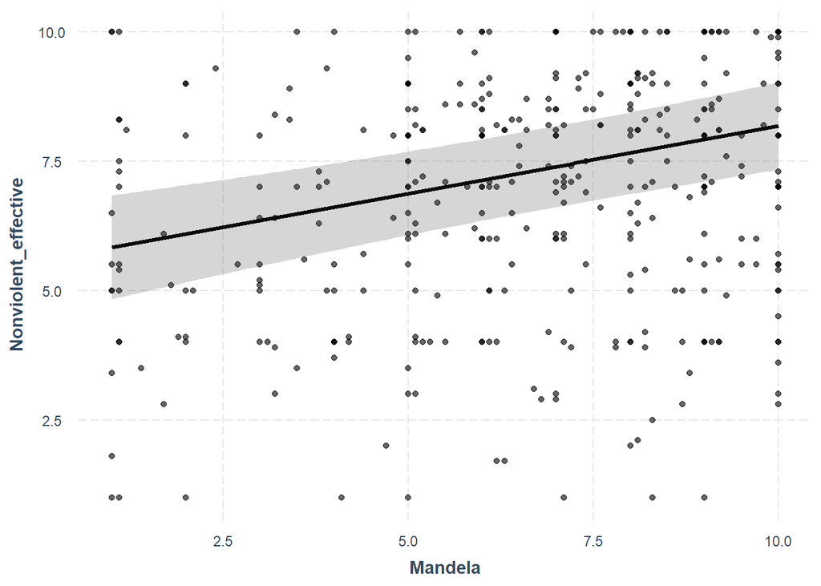

```r
effect_plot(ml_OLS3, pred = Mandela, interval = TRUE, plot.points = TRUE)
```

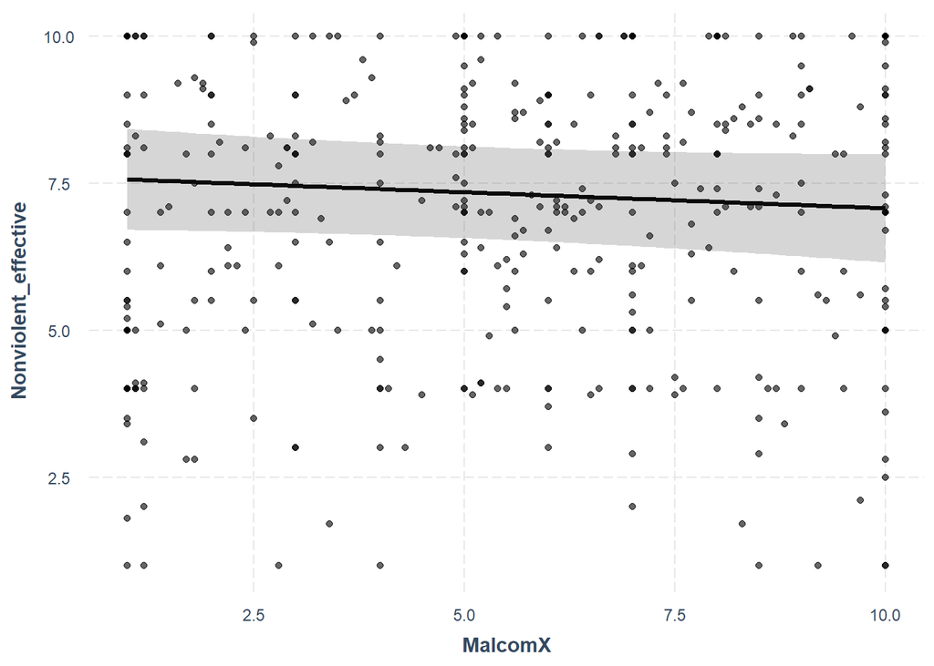

```r
effect_plot(ml_OLS3, pred = MalcomX, interval = TRUE, plot.points = TRUE)
```

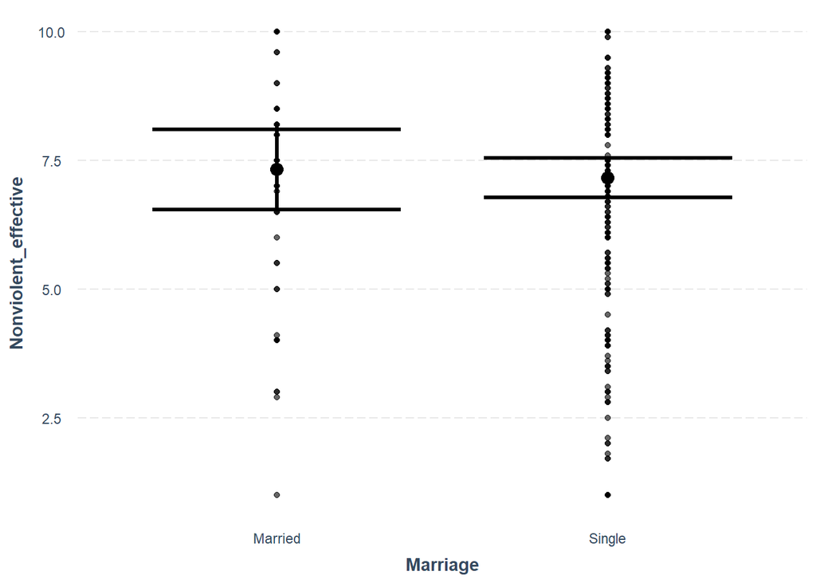

```r
effect_plot(ml_OLS3, pred = Marriage, interval = TRUE, plot.points = TRUE)
```

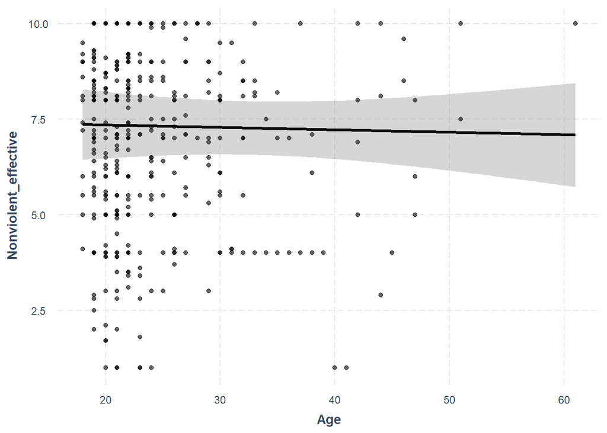

```r
effect_plot(ml_OLS3, pred = Age, interval = TRUE, plot.points = TRUE)
```

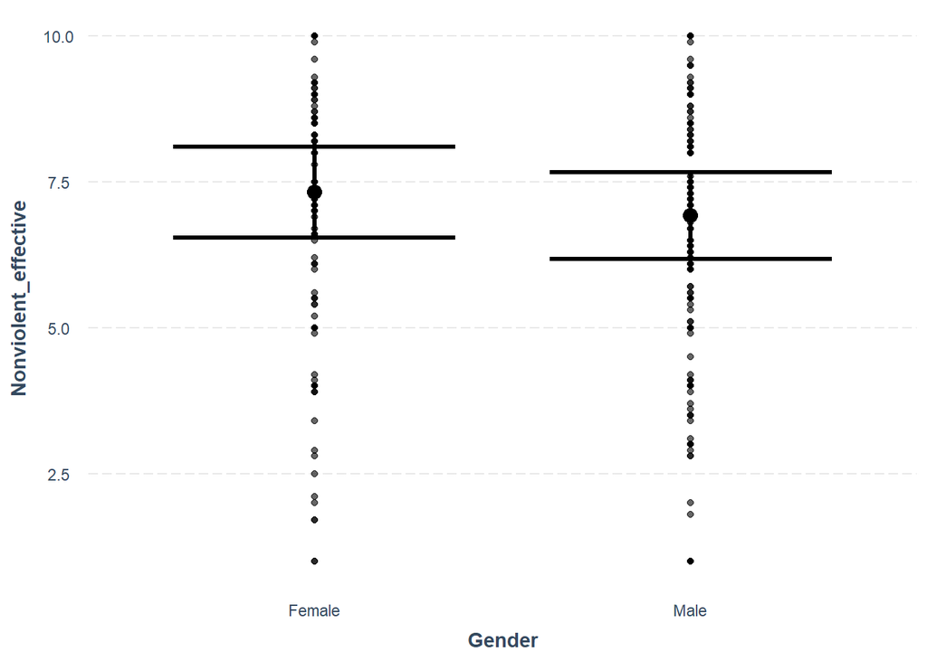

```r
effect_plot(ml_OLS3, pred = Gender, interval = TRUE, plot.points = TRUE)
```

## Question 4)

It is time to put to the test the validity of this model by checking its ‘’BLUEness’’ (the Gauss-Markov’s BLUE assumptions). This is very important and necessary because if it were not to pass this test, not even a R square value of 100 would save us from having a future paper rejected. Here R studio’s libraries and coding come to the rescue, as usual, with some very much needed visual help.

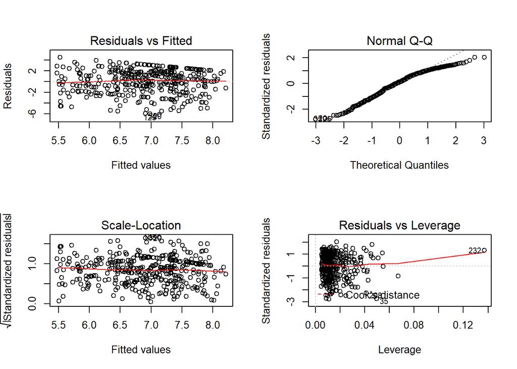

```r
OLS3_broomed = augment(ml_OLS3)

ml_OLS3_diag_metrics = augment(ml_OLS3)

par(mfrow= c(2,2))

plot(ml_OLS3)
```

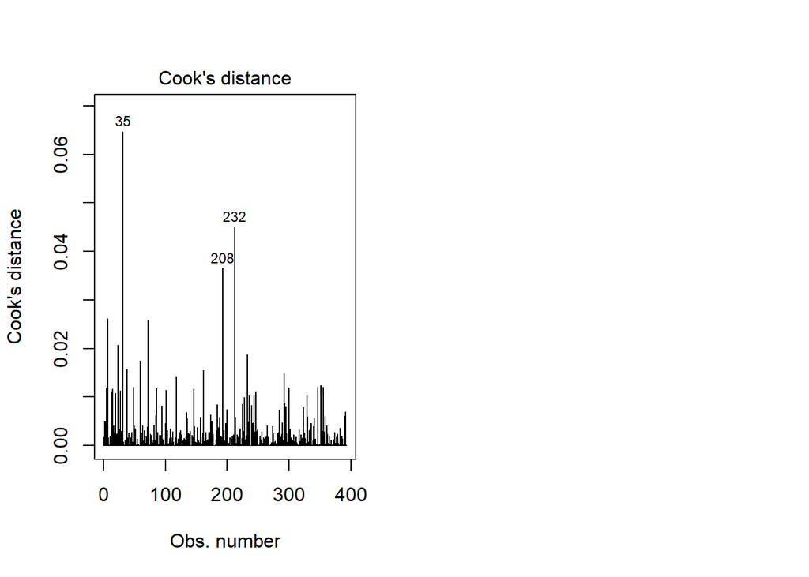

```r
par(mfrow = c(1, 2))

plot(ml_OLS3, 4)
```

Let us address each plot individually

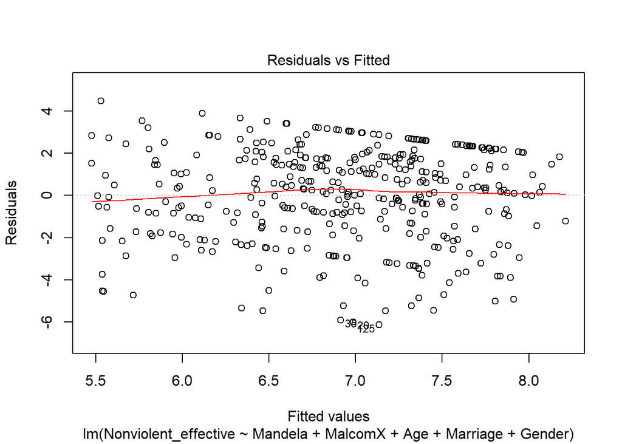

```r
plot(ml_OLS3, 1)
```

This plot is telling us that the linearity assumption is respected. How? We can observe a scatterplot where our line cut almost completely straightforward horizontally through the sample. Indeed, as we have studied, the trend line here is close enough to a horizontal line, with no relevant departures, thus confirming a linear relationship. So far so good.

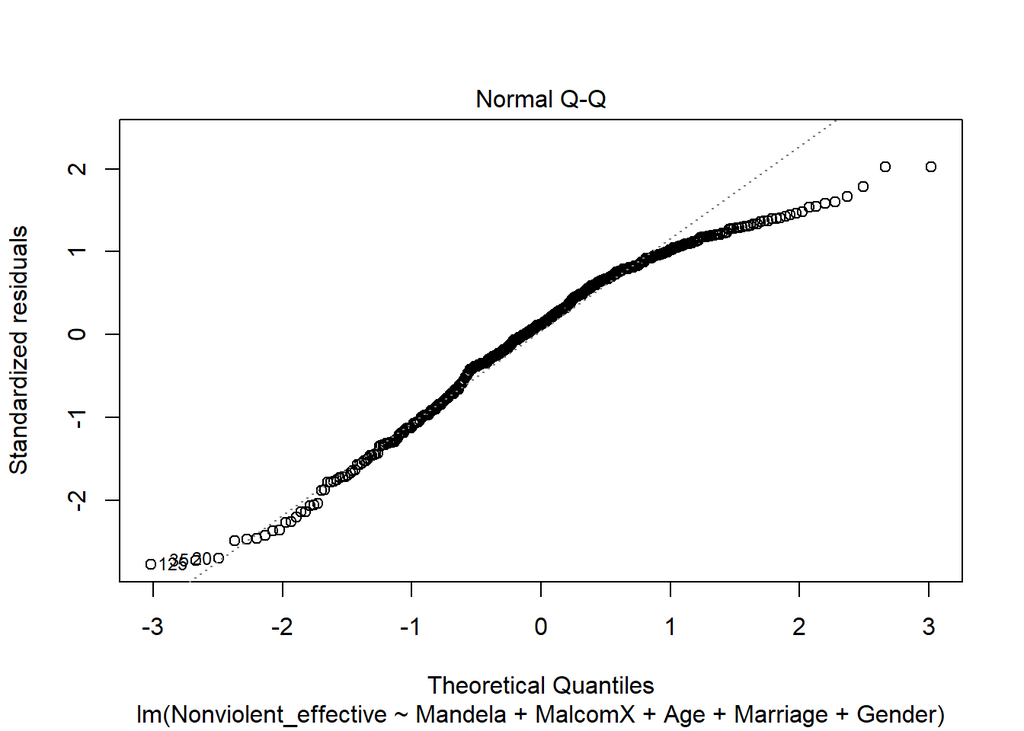

```r
plot(ml_OLS3, 2)
```

In this case, to be satisfied with our model, we must check if the residuals are normally distributed. Visually speaking, this means that an acceptable model should have its residuals points portraying on the plot a consistent trend reminiscent of a line with a 45 degrees slope. This seems to be the case, and thus we can move forward to the next step. Still, we can clearly observe some departures from the ideal line, possibly suggesting the presence of some outliers. This will be investigated later.

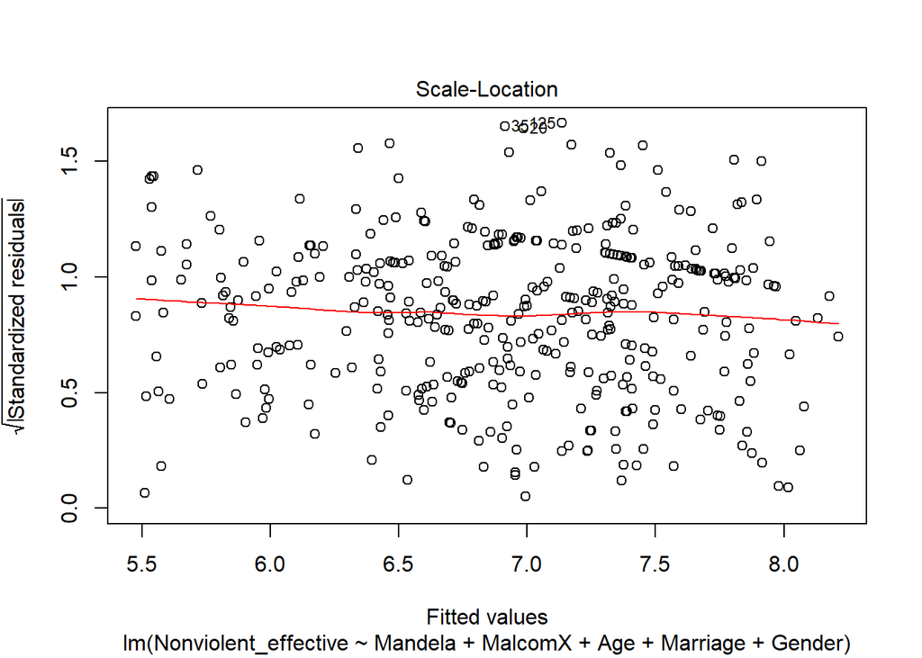

```r
plot(ml_OLS3, 3)
```

With this plot we are testing for homoskedacity. That is to say, we are hoping to witness homogeneity in the variance of the residuals around a horizontal line. Were it not the case, say for example a scatterplot with points spread in a way resembling a cone figure, we would be facing heteroskedacity. Luckily enough, from the plot above we can indeed see a homogenous spread of the points across a more or less horizontal line. We can safely move to the next step: effectively checking for the presence of outliers that could endanger our results.

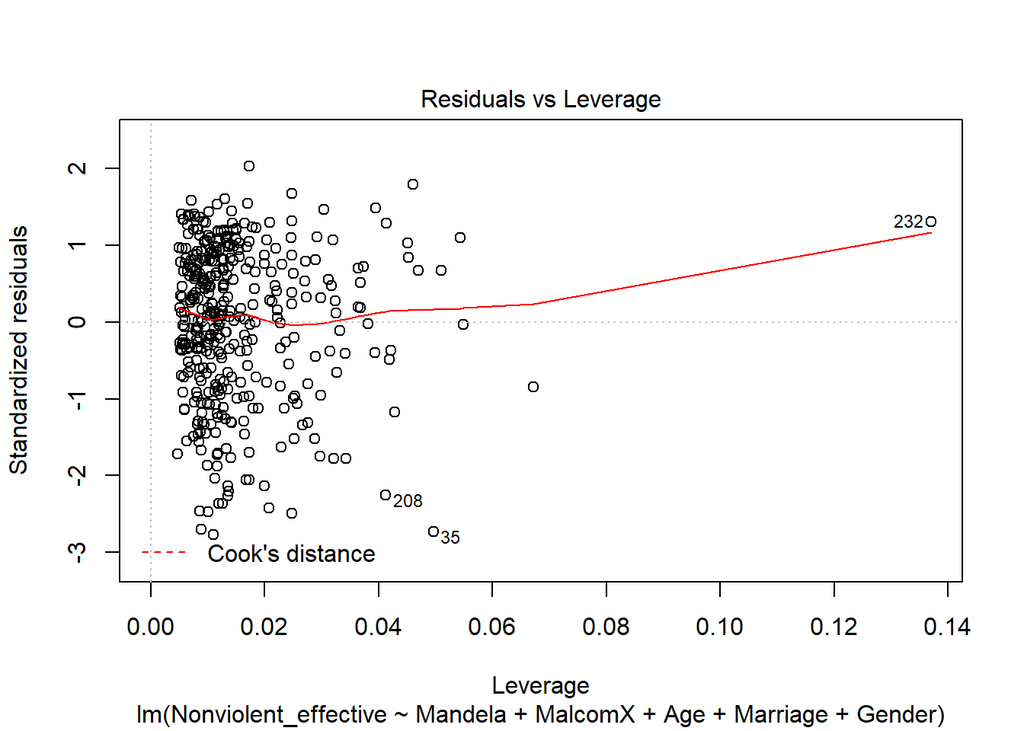

```r
plot(ml_OLS3, 5)
```

As mentioned above, we must now check who is potentially messing with the validity of our model, which means controlling for the presence of outliers that could substantially influence our results, and consequentially, our interpretations and inferences. Once more, what we would like to observe is a somewhat homogeneous trend around a horizontal (enough) line. However, our ‘’Thin Red Line’’ here does not entirely met our expectations, clearly showing the presence of some relevant outliers. To correct this, we will need to identify them and eventually removed them from the data.

To start, as suggested in the last class, we can use the Cook’s distance.

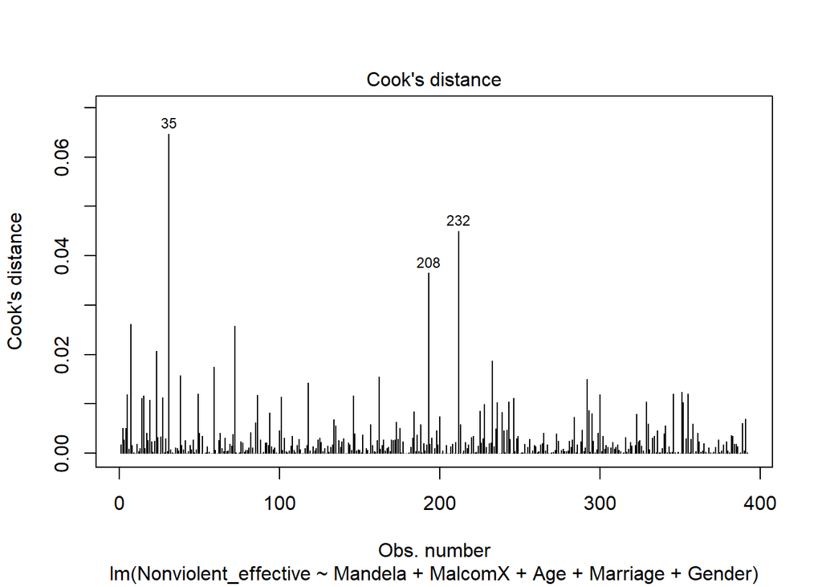

```r
plot(ml_OLS3, 4)
```

```r
ml_OLS3_diag_metrics %>% top_n(3, wt = .cooksd)
```

```
## # A tibble: 3 x 14
##   .rownames Nonviolent_effe~ Mandela MalcomX   Age Marriage Gender .fitted
##   <chr>                <dbl>   <dbl>   <dbl> <int> <fct>    <fct>    <dbl>
## 1 35                       1    7.10      10    41 Single   Female    6.91
## 2 208                      3   10          3    25 Married  Male      7.91
## 3 232                     10   10          7    61 Single   Male      7.31
## # ... with 6 more variables: .se.fit <dbl>, .resid <dbl>, .hat <dbl>,
## #   .sigma <dbl>, .cooksd <dbl>, .std.resid <dbl>
```

On the Cook’s distance plot we can immediately see confirmed the presence of three highly relevant outliers, that are easily confirmed by calling the relative diagnostic metrics.

The next step will be to remove those three outliers and run our OLS3 model once more, but with the cleaned dataset.

```r
Clean_Data = Data[-c(35, 208, 232), ]

ml_OLS3_NO=lm(Nonviolent_effective~Mandela+MalcomX+Marriage+Age+Gender, data=Clean_Data)

summ(ml_OLS3_NO)
```

```
## MODEL INFO:
## Observations: 389 (44 missing obs. deleted)
## Dependent Variable: Nonviolent_effective
## Type: OLS linear regression
##
## MODEL FIT:
## F(5,383) = 7.12, p = 0.00
## R² = 0.08
## Adj. R² = 0.07
##
## Standard errors: OLS
## ---------------------------------------------------
##                         Est.   S.E.   t val.      p
## -------------------- ------- ------ -------- ------
## (Intercept)             6.24   0.89     7.04   0.00
## Mandela                 0.26   0.05     4.91   0.00
## MalcomX                -0.05   0.05    -1.07   0.28
## MarriageSingle         -0.29   0.41    -0.71   0.48
## Age                    -0.01   0.02    -0.43   0.67
## GenderMale             -0.43   0.23    -1.83   0.07
## ---------------------------------------------------
```

To test if removing the outliers represents the best strategy, now we must re-run the BLUEness test and observe if we get different results

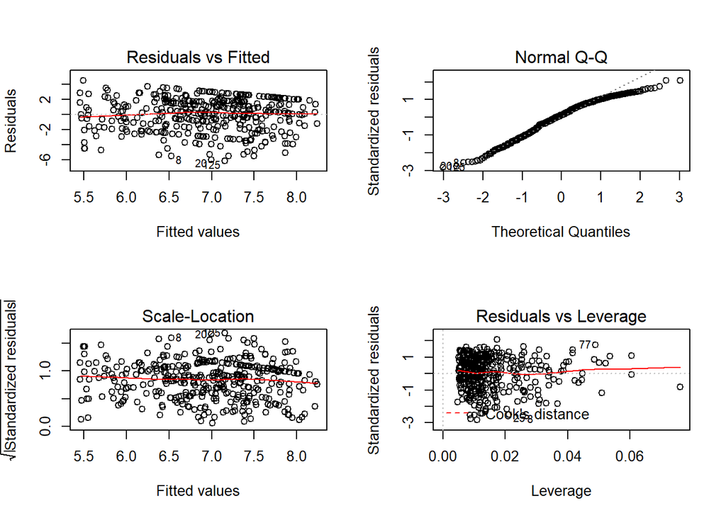

```r
OLS3_NO_broomed = augment(ml_OLS3_NO)

ml_OLS3_NO_diag_metrics = augment(ml_OLS3_NO)

par(mfrow= c(2,2))

plot(ml_OLS3_NO)
```

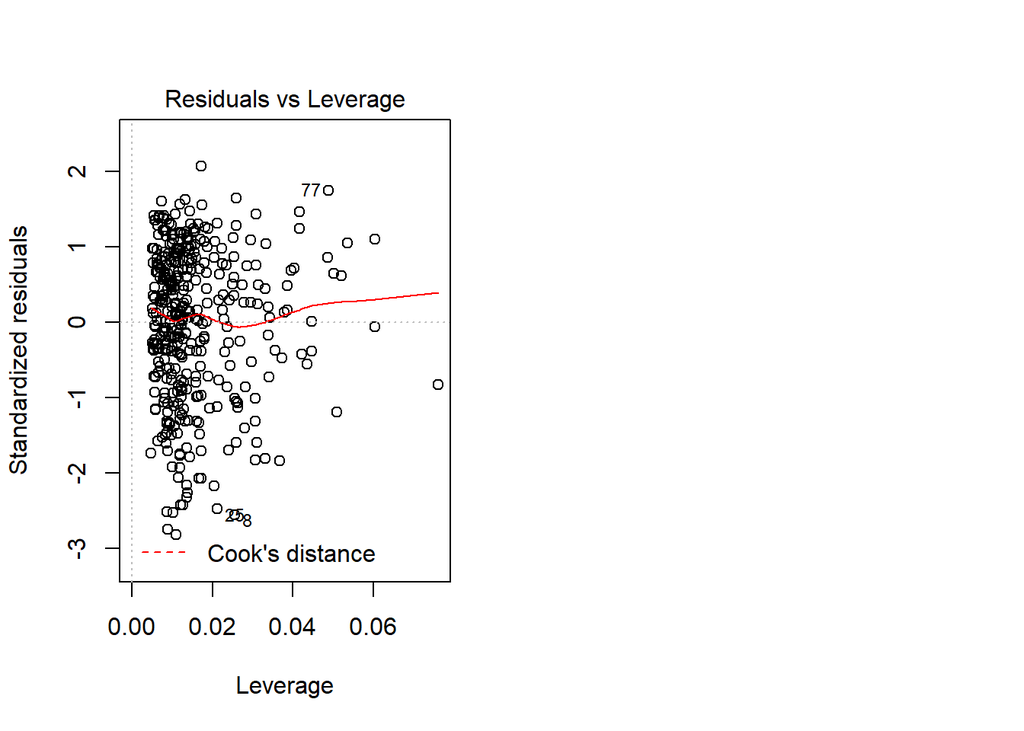

```r
par(mfrow = c(1, 2))

plot(ml_OLS3_NO, 5)
```

As we can observe, removing those outliers has slightly improved our situation. However, the Residuals vs Leverage plot still shows the presence of some other outliers, making us wonder if a further purge of these outliers would help to finally solve the issue. It is worth a try:

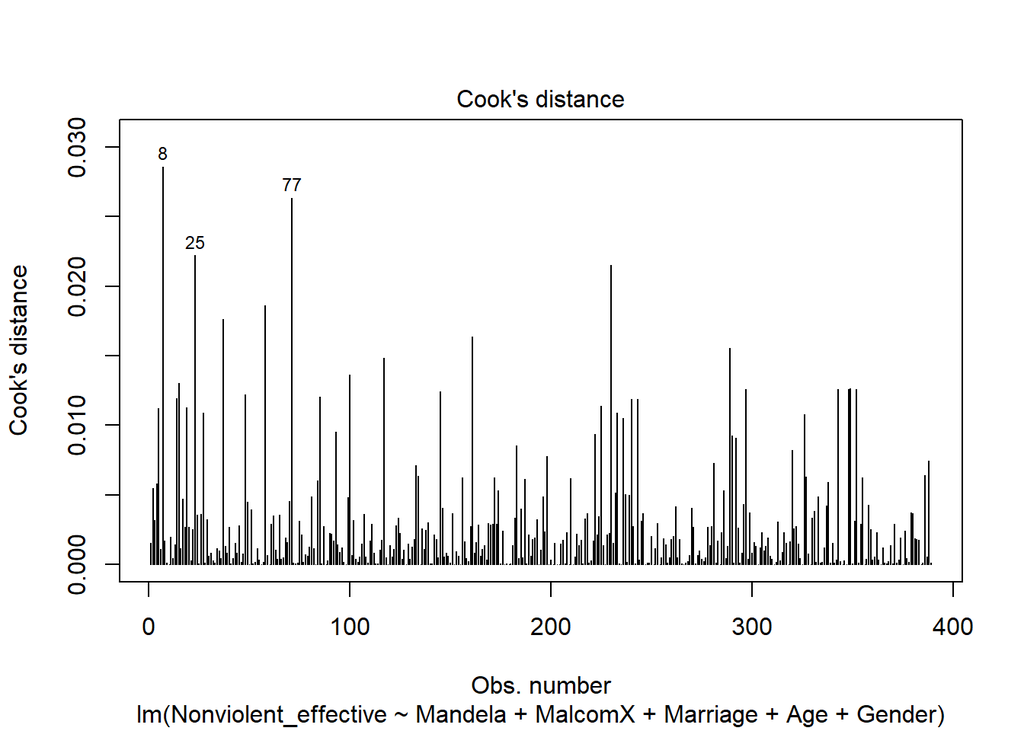

```r
plot(ml_OLS3_NO, 4)
```

```r
ml_OLS3_NO_diag_metrics %>% top_n(3, wt = .cooksd)
```

```
## # A tibble: 3 x 14
##   .rownames Nonviolent_effe~ Mandela MalcomX Marriage   Age Gender .fitted
##   <chr>                <dbl>   <dbl>   <dbl> <fct>    <int> <fct>    <dbl>
## 1 8                        1    5        4   Married     40 Male      6.53
## 2 25                       1    4.10     8.5 Single      21 Female    6.38
## 3 77                      10    1.1      1.1 Married     23 Female    6.25
## # ... with 6 more variables: .se.fit <dbl>, .resid <dbl>, .hat <dbl>,
## #   .sigma <dbl>, .cooksd <dbl>, .std.resid <dbl>
```

```r
Clean_Data_2 = Data[-c(8,25,35,77,208,232), ]

ml_OLS3_NO_2=lm(Nonviolent_effective~Mandela+MalcomX+Marriage+Age+Gender, data=Clean_Data_2)
```

We shall test one last time for the BLUEness

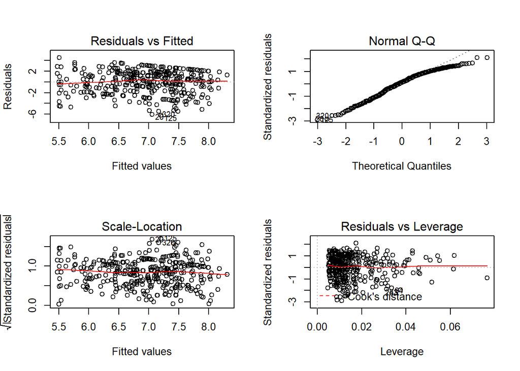

```r
OLS3_NO_2_broomed = augment(ml_OLS3_NO_2)

ml_OLS3_NO_2_diag_metrics = augment(ml_OLS3_NO_2)

par(mfrow= c(2,2))

plot(ml_OLS3_NO_2)
```

[output not shown]

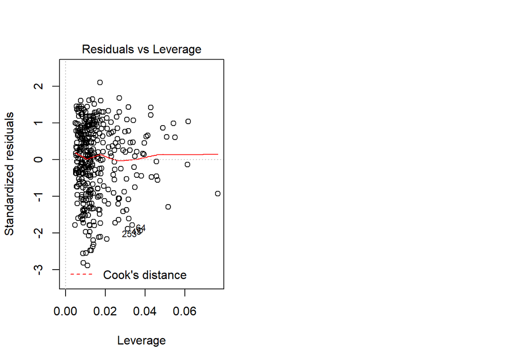

```r
par(mfrow = c(1, 2))

plot(ml_OLS3_NO_2, 5)

summ(ml_OLS3_NO_2)
```

As we can observe from the last Residuals vs Leverage plot, an additional removal of outliers (for a total of 6 removed outliers) clearly has helped us. In fact, we can witness a more even distribution around a more clearly horizontal line without any striking departures as we have instead witnessed in the first two test we have run. It Is also interesting to observe that R square has increased of another 1%, starting from a 6% of OLS1 to a 9% of OLS3_NO_2.

## Question 5)

For this last question, we will try to observe if the effect of Religiosity on the opinion/attitude toward the effectiveness of non-violent resistance is mediated by the marital status (single or married) of the participants. To do this, we will create the relative interaction model as showed in HW3, and then we shall generate the related predicted effects plot. (To add some spice, we will run the model by calling both the original dataset and the second cleaned dataset, Clean_Data_2, but not much will change)

```r
ml_OLS4=lm(Nonviolent_effective~Religiosity+Marriage+Religiosity*Marriage, data=Data)

summ(ml_OLS4)
```

```
## MODEL INFO:
## Observations: 435 (1 missing obs. deleted)
## Dependent Variable: Nonviolent_effective
## Type: OLS linear regression
##
## MODEL FIT:
## F(3,431) = 2.23, p = 0.08
## R² = 0.02
## Adj. R² = 0.01
##
## Standard errors: OLS
## ---------------------------------------------------------------
##                                     Est.   S.E.   t val.      p
## -------------------------------- ------- ------ -------- ------
## (Intercept)                         7.25   0.62    11.67   0.00
## Religiosity                        -0.05   0.10    -0.50   0.62
## MarriageSingle                     -0.80   0.66    -1.21   0.23
## Religiosity:MarriageSingle          0.15   0.11     1.38   0.17
## ---------------------------------------------------------------
```

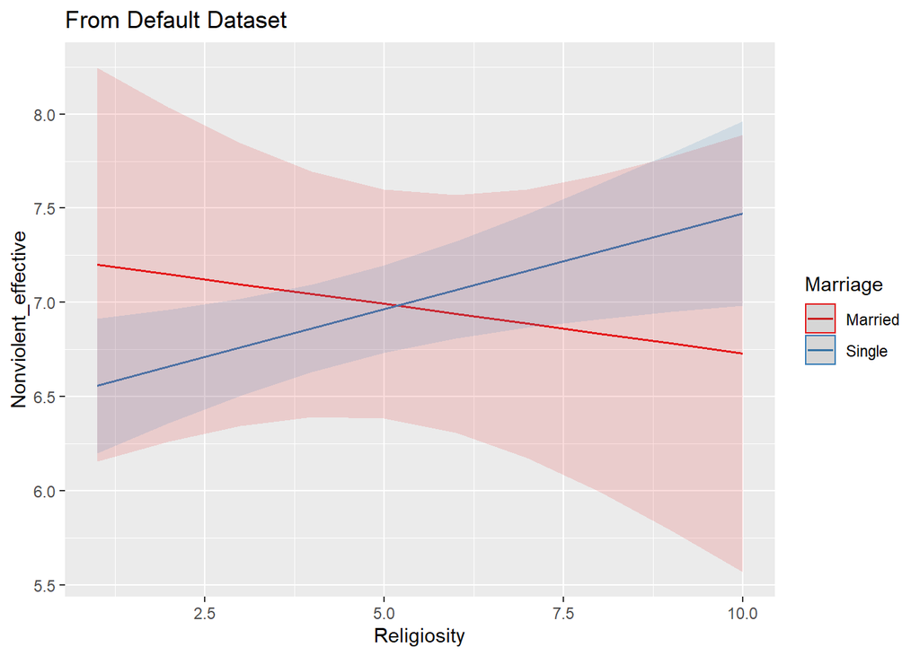

```r
plot_model(ml_OLS4, type = "pred", terms = c("Religiosity", "Marriage"),title = 'From Default Dataset')
```

```r
ml_OLS5=lm(Nonviolent_effective~Religiosity+Marriage+Religiosity*Marriage, data=Clean_Data_2)

summ(ml_OLS5)
```

```
## MODEL INFO:
## Observations: 429 (1 missing obs. deleted)
## Dependent Variable: Nonviolent_effective
## Type: OLS linear regression
##
## MODEL FIT:
## F(3,425) = 2.52, p = 0.06
## R² = 0.02
## Adj. R² = 0.01
##
## Standard errors: OLS
## ---------------------------------------------------------------
##                                     Est.   S.E.   t val.      p
## -------------------------------- ------- ------ -------- ------
## (Intercept)                         7.52   0.63    12.02   0.00
## Religiosity                        -0.08   0.10    -0.74   0.46
## MarriageSingle                     -1.04   0.66    -1.58   0.11
## Religiosity:MarriageSingle          0.18   0.11     1.61   0.11
## ---------------------------------------------------------------
```

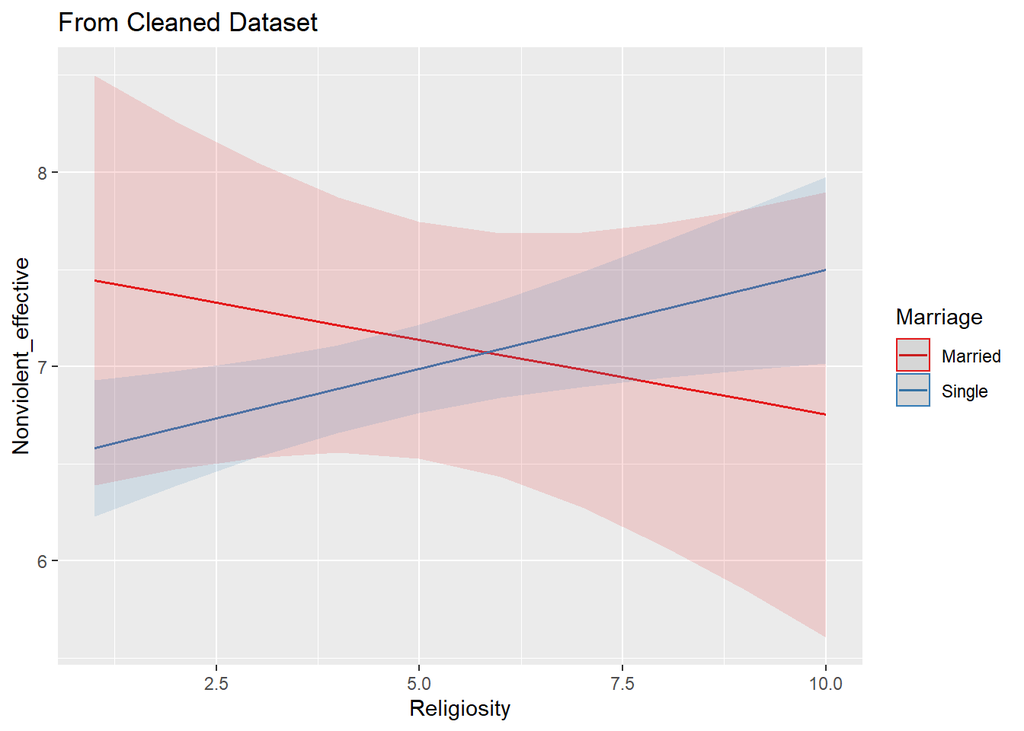

```r
plot_model(ml_OLS5, type = "pred", terms = c("Religiosity", "Marriage"),title = 'From Cleaned Dataset')
```

As both the two summaries immediately show, no matter how fancy the predicted effects plots may look, none of the independent/control variables possess a statistically significant value. Were it not enough, for both models the value of R square is almost as low as it gets (2%), suggesting us that this model does not possess almost any explanatory power. Furthermore, as we can see, using the cleaned datasets basically does not change much. However, if we were to deduce our inferences by simply looking at the plots, it would appear that for married participants, the higher their religiosity, the lower their opinion/support on the effectiveness of non-violent resistance, whereas for single participants the trend would be the opposite, where at higher levels of religiosity corresponds a higher opinion/support for the effectiveness of non-violent resistance.

Too bad we cannot say if this plot is trying to warn us about religiosity or about marriage